# The Power of Graphs in Network Protocols

##### Author: Jason Kronemeyer

Graphs are a powerful tool for modeling and visualizing networks, offering an intuitive representation of complex relationships between entities. In the realm of network protocols, such as the Spanning Tree Protocol (STP) invented by Radia Perlman, graphs help illustrate the connections and hierarchical structure of the network. By representing devices as nodes and connections as edges, graphs make it easier to understand and optimize network performance, ensuring stability and efficiency.

## Why Use Graphs for Networks?

1. **Intuitive Representation**: Nodes represent entities (e.g., devices), and edges represent connections.
2. **Complexity Management**: Graphs handle complex structures, making it easier to visualize intricate networks.
3. **Pathfinding and Optimization**: Graph algorithms (shortest path, spanning tree, etc.) optimize routes and improve efficiency.
4. **Scalability**: Graphs scale to large datasets, representing vast networks without losing clarity.
5. **Versatility**: Graphs model hierarchical, cyclic, and multi-dimensional relationships.
6. **Visual Insights**: Visualizations reveal patterns, clusters, and anomalies not apparent from raw data.

## The Spanning Tree Protocol (STP)

The Spanning Tree Protocol (STP) is a network protocol designed to prevent loops in Ethernet networks by creating a loop-free logical topology. It works by identifying and disabling redundant paths, ensuring there is only one active path between any two network nodes. This helps maintain network stability and efficiency.

**Radia Perlman** invented STP in 1984 and is often called the "Mother of the Internet" for her contributions to network protocols.

### Representing STP as a Graph

To represent STP as a graph:

1. **Nodes**: Each network device (e.g., switches, bridges) is a node.
2. **Edges**: Connections between devices are edges.
3. **Root Node**: The root bridge is the root node of the spanning tree.
4. **Path Costs**: Weights on edges represent path costs to the root.
5. **Tree Structure**: The graph is acyclic and connected (one path between any two nodes).

#### Example Topology

```
    Root Bridge
       /   \
      /     \
     A       B
    / \     / \
   C   D   E   F
```

- **Root Bridge** is the root node.
- **A** and **B** connect directly to the root.
- **C**, **D**, **E**, and **F** connect to **A** and **B**.

### What Graph Algorithm Does Spanning Tree Use?

The Spanning Tree Protocol (STP) uses a **minimum spanning tree (MST)** algorithm to determine the subset of network links that form a loop-free topology. In graph theory, a minimum spanning tree is a subset of the edges that connects all the nodes together, without any cycles and with the minimum possible total edge weight.

Common algorithms to find a minimum spanning tree include:

- **Kruskal's Algorithm**
- **Prim's Algorithm**

STP does not implement these algorithms directly, but its distributed process achieves the same result: it elects a root bridge and disables redundant links so that only the minimum set of connections remains, forming a spanning tree.

### Demonstrating Spanning Tree Protocol Disabling a Redundant Link

#### Example using NetworkX visualized with PyGraghViz

Suppose there is a redundant connection between nodes D and E. The Spanning Tree Protocol (STP) will detect that there are two possible paths between the Root Bridge and some nodes (e.g., D and E), and will disable one of the redundant links to prevent loops. In the visualization below, the redundant link is shown in red and dashed to indicate it is disabled by STP.

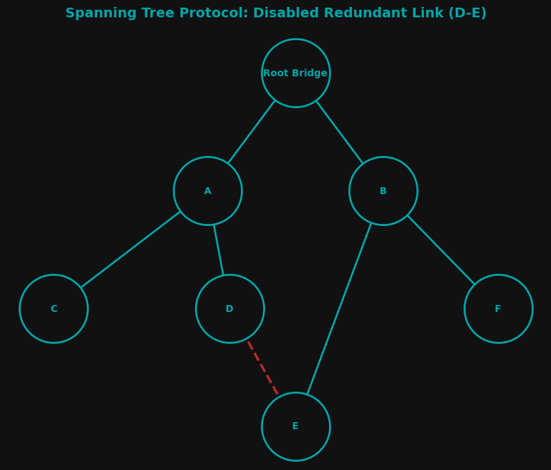

```python
import networkx as nx
import matplotlib.pyplot as plt
import pygraphviz as pgv

# Merit Network Color palette
primary_colors = {
    "Electric Blue": "#00A5A8",
    "Charcoal": "#111112"
}
secondary_colors = {
    "Cyber Red": "#B72E26",
    "Broadband Blue": "#CFEBED",
    "Light Grey": "#D9D9D9"
}

# Create the graph
G = nx.Graph()
G.add_nodes_from(["Root Bridge", "A", "B", "C", "D", "E", "F"])
edges = [
    ("Root Bridge", "A"),
    ("Root Bridge", "B"),
    ("A", "C"),
    ("A", "D"),
    ("B", "E"),
    ("B", "F"),
    ("D", "E")  # Redundant link
]
G.add_edges_from(edges)

# Identify the redundant (to be disabled) link
redundant_link = ("D", "E")

# Draw the graph using a tree layout
pos = nx.drawing.nx_agraph.graphviz_layout(G, prog="dot")

# Draw all edges except the redundant one
normal_edges = [e for e in G.edges if e != redundant_link and e != (redundant_link[1], redundant_link[0])]
nx.draw_networkx_edges(
    G, pos, edgelist=normal_edges, edge_color=primary_colors["Electric Blue"], width=2
)

# Draw the redundant (disabled) edge in Cyber Red and dashed
nx.draw_networkx_edges(
    G, pos, edgelist=[redundant_link], edge_color=secondary_colors["Cyber Red"], style='dashed', width=2.5
)

# Draw nodes and labels
nx.draw_networkx_nodes(
    G, pos, node_color=primary_colors["Charcoal"], edgecolors=primary_colors["Electric Blue"], linewidths=2, node_size=5000
)
nx.draw_networkx_labels(
    G, pos, font_size=10, font_color=primary_colors["Electric Blue"], font_weight='bold'
)

# Set plot background color to Charcoal and text to a contrasting color (Broadband Blue)
fig = plt.gcf()
fig.set_size_inches(10, 8)
fig.patch.set_facecolor(primary_colors["Charcoal"])
ax = plt.gca()
ax.set_facecolor(primary_colors["Charcoal"])

# Use plt.title to set the title with color
plt.title(
    "Spanning Tree Protocol: Disabled Redundant Link (D-E)",
    color=primary_colors["Electric Blue"],
    fontsize=14, fontweight='bold', loc='center', pad=20
)
plt.axis('off')
plt.show()
```

Graph Color Scheme Courtesy Merit Network

## References

1. [Radia Perlman - Wikipedia](https://en.wikipedia.org/wiki/Radia_Perlman)
2. [networkx: Tree Graph Documentation](https://networkx.org/documentation/stable/reference/algorithms/tree.html)
3. [Cisco Networking: Spanning Tree Protocol](https://www.wwt.com/learning-path/cisco-networking-spanning-tree-protocol)
4. [Cheatsheet: Spanning Tree Protocol (STP) on Cisco Learning Network](https://learningnetwork.cisco.com/s/article/cheatsheet-spanning-tree-protocol-stp-x)
5. [NetworkLessons.com: Spanning-Tree](https://networklessons.com/spanning-tree)
6. [Merit Network: Style Guide](https://www.merit.edu)